# Documento de Visualización de Datos ELSOC Longitudinales con ggplot2

Practicantes ELSOC 2021

02-06-2021

Abstract

El presente documento tiene como objetivo explicar los pasos para lograr la visualización de los datos óptima a través del paquete `ggplot2` . En este sentido, el documento se divide en dos partes. La primera corresponde a la preparación de la base de datos, en donde se realizarán modificaciones a la base de datos para su posterior uso en los gráficos. La segunda parte se encarga de la visualización de datos con `ggplot2`, en donde se expondrán tres tipos de gráficos: de barra, alluvial y de líneas.

## 1. Preparación de datos

### b. Cargar base de datos desde repositorio en Dataverse

```r
load(url("https://dataverse.harvard.edu/api/access/datafile/4606527")) #cargar bbdd desde url oficial
                                                                       #alojado en dataverse
```

### c. Selección de variables y filtrado de datos

Para el desarrollo del instructivo se trabajará con las siguientes variables de ELSOC:

- `id`: número único que identifica a cada persona encuestada
- `ponderador01`: ponderador ajustado por población
- `ponderador02`: ponderador ajustado por población y sexo
- `m0_sexo`: sexo de la persona encuestada
- `m0_edad`: edad de la persona encuestada
- `m01`: nivel de educación de la persona encuestada
- `d01`: estatus social subjetivo de la persona encuestada
- `m02`: situación ocupacional de la persona encuestada
- `segmento`: manzanas o bloques de la muestra.
- `estrato`: tipo de ciudad de la persona encuestada
- `region`: región de residencia de la persona encuestada
- `c16`: identificación con partidos políticos de la persona encuestada
- `c17`: identificación con coalición política de la persona encuestada
- `c28`: grado de acuerdo con la necesidad de cambiar la constitución actual de la persona encuestada
- `c05`: nivel de confianza con el presidente de la república de la persona encuestada
- `c05_02`: nivel de confianza con los partídos políticos de la persona encuestada
- `c05_03`: nivel de confianza con los carabineros de la persona encuestada

Todas las cuales tienen agregado el sufijo "_w0[X]" que indica la ola de medición de la variable, y donde **[X]** corresponde al número de ola, pudiendo tomar los valores **1**, **2**, **3** y **4**, asociados a las olas 2016, 2017, 2018 y 2019 respectivamente.

Finalmente, para trabajar con datos panel resulta fundamental filtrar las variables por atrición y tipo de casos, donde:

- `tipo_atricion`: indica cantidad de encuestados que responde a cada ola incluidas en la versión de la base de datos combinada.
- `tipo_caso`: clasifica los casos según su consistencia intertemporal en los atributos sexo, edad y educación.

En específico, nos quedaremos sólo con aquellos encuestados que respondieron en las cuatro olas de ELSOC (`tipo_atricion`=1) y eliminaremos de la muestra los casos con inconsistencias mayores (`tipo_caso`=2).

```r
elsoc_wide <- elsoc_wide_2016_2019 %>% dplyr::filter(tipo_atricion==1 & tipo_caso !=2)
              #filtrar atrición entre 2016-19 y casos c/inconsistencias mayores

elsoc_wide <- elsoc_wide %>% dplyr::select(idencuesta, #identificador individual
                             ponderador01_w01,ponderador01_w02,ponderador01_w03,ponderador01_w04,
                                                                            #ponderador población
                             ponderador02_w01,ponderador02_w02,ponderador02_w03,ponderador02_w04,
                                                                                #ponderador sexo
                             m0_sexo_w01,m0_sexo_w02,m0_sexo_w03,m0_sexo_w04, #sexo
                             m0_edad_w01,m0_edad_w02,m0_edad_w03,m0_edad_w04, #edad
                             m01_w01,m01_w02,m01_w03,m01_w04, #nivel de educación
                             d01_01_w01,d01_01_w02,d01_01_w03,d01_01_w04, #estatus social subjetivo
                             m02_w01,m02_w02,m02_w03,m02_w04, #situación ocupacional
                             segmento_w01,segmento_w02,segmento_w03,segmento_w04, #manzana o bloque
                             estrato_w01,estrato_w02,estrato_w03,estrato_w04, #ciudad
                             region_w01,region_w02,region_w03,region_w04, #región
                             c16_w01,c16_w02,c16_w03,c16_w04, #indentificación con partido político
                             c17_w01,c17_w02,c17_w03,c17_w04, #intentificación con coalición política
                             c28_w01,c28_w02,c28_w03,c28_w04, #de acuerdo con cambiar la constitución actual
                             c05_08_w01,c05_08_w02,c05_08_w03,c05_08_w04, #confianza en el presidente
                             c05_02_w01,c05_02_w02,c05_02_w03,c05_02_w04, #confianza en partidos políticos
                             c05_03_w01,c05_03_w02,c05_03_w03,c05_03_w04) #confianza en carabineros
```

### d. Transformar base de datos de wide a long

Antes de trasformar la base de datos de wide a long, se debe tener claro el nombre de la etiqueta de periodo asociada a cada variable. En este caso, como se indicó, dicha etiqueta es el sufijo "_w0“, habiendo cuatro casos asociados a cada ola:”_w01“,”_w02“,”_w03" y "_w04". Estos corresponden al años 2016, 2017, 2018 y 2019, respectivamente. Teniendo esta información clara se puede completar los argumentos de la función `long_panel` del paquete `panelr`. Para mayor información del uso de `long_panel` visitar el [link](https://rdrr.io/cran/panelr/man/long_panel.html).

#### Estructura de la función long panel

[nueva bbdd long] <- long_panel(data = [bbdd wide], prefix = “[prefijo de la etiqueta]”, begin = [etiqueta de la primera ola], end = [etiqueta de la última ola], label_location = “[ubicación de la ola en la etiqueta]”, id = “[indentificador individual]”, wave =“[nombre de la nueva variable asociada al periodo]”).

```r
elsoc_long <- long_panel(data = elsoc_wide, #base de datos formato wide
                         prefix = "_w0", #caracteres antes de la etiqueta de cada ola
                         begin = 1, #etiqueta de la primera ola
                         end = 4, #etiqueta de la última ola
                         label_location = "end", #indica donde se localiza la etiqueta asociada a la ola
                         id = "idencuesta", #indica identificador individual
                         wave = "ola") #nombre que tomará la variable que indica periodo.
```

Finalmente, filtramos la base de datos long de casos perdidos.

```r
elsoc_long[elsoc_long==-999 | elsoc_long==-888] <- NA #recodificar No sabe y No responde en NA
sum(is.na(elsoc_long)) #indica cantidad de NA
```

```
## [1] 1142
```

```r
elsoc_long <- na.omit(elsoc_long) #filtrar NA de la BBDD
sum(is.na(elsoc_long)) #indica cantidad de NA
```

```
## [1] 0
```

### e. Recodificación de variables

A continuación, se recodificarán las categorías de respuesta y se etiquetarán las variables seleccionadas.

```r
#Recode VAR "ola" correspondiente a la ola de medición.
elsoc_long$ola <- factor(elsoc_long$ola,labels = c('2016', '2017', '2018', '2019'))
elsoc_long$ola <- sjlabelled::set_label(elsoc_long$ola, label = c("Ola de Medición")) #etiquetamos variable

#Recode VAR "m0_sexo" / rename "sexo"
elsoc_long$sexo <- factor(elsoc_long$m0_sexo,labels = c('Hombre', 'Mujer'))
elsoc_long$sexo <- sjlabelled::set_label(elsoc_long$sexo, label = c("Tipo de sexo")) #etiquetamos variable

#Recode VAR "m0_edad" / rename "edad"
elsoc_long$edad <- factor(car::recode(elsoc_long$m0_edad, "18:29=1;30:49=2;50:64=3;65:150=4"),
                           labels = c('18-29', '30-49', '50-64', '65 o más'))
elsoc_long$edad <- sjlabelled::set_label(elsoc_long$edad, label = c("Edad en Tramos")) #etiquetamos variable

#Recode VAR "m01" nivel educacional / rename "educacion"
elsoc_long$educacion <- car::recode(elsoc_long$m01,"c(1,2,3)=1;c(4,5)=2;c(6,7)=3;c(8,9,10)=4")
elsoc_long$educacion <- factor(elsoc_long$educacion,labels = c("Basica","Media","Tecnica","Universitaria"))
elsoc_long$educacion <- sjlabelled::set_label(elsoc_long$educacion, label = c("Nivel Educacional")) #etiquetamos variable

#Recode VAR "d01_01" estatus social subjetivo / raneme "estatus"
elsoc_long$estatus<- factor(car::recode(elsoc_long$d01_01, "0:4=1;5=2;6:10=3"),
                          labels = c('Bajo','Medio','Alto'))
elsoc_long$estatus <- sjlabelled::set_label(elsoc_long$estatus, label = c("Estatus Social Subjetivo")) #etiquetamos variable

#Recode VAR "m02" situación ocupacional / rename "socup"
elsoc_long$socup <- factor(car::recode(elsoc_long$m02,"c(1,2,3) = 1; 7 = 2; 6 = 3; 5 = 4; c(4, 8, 9) = 5"),
                           labels = c("Trabajo remunerado", "Trabajo doméstico no remunerado", "Desempleado/a", "Jubilado/a o pensionado/a",
                           "Otras categorías"))
elsoc_long$socup <- sjlabelled::set_label(elsoc_long$socup, label = c("Situación Ocupacional")) #etiquetamos variable

#Recode VAR "estrato" que refiere al tipo de ciuda / rename "tipo de ciudad"
elsoc_long$tipo_ciudad <- factor(elsoc_long$estrato, labels = c('Gran Santiago', 'Gran Valparaíso', 'Gran Concepción', 'Ciudades grandes', 'Ciudades medianas', 'Ciudades pequeñas'))
elsoc_long$tipo_ciudad <- sjlabelled::set_label(elsoc_long$estrato, label = c("Tipo de ciudad")) #etiquetamos variable

#Recode VAR "region" correspondiente a regiones del país/ raname "zona" relativa a macrozona geográfica.
elsoc_long$zona  <- car::recode(elsoc_long$region,"c('Tarapaca','Antofagasta','Atacama','Coquimbo','Arica')= 1;c('Valparaiso','Lib. Gral. B. Ohiggins','B. Ohiggins', 'Maule','Bio Bio')= 2;c('Araucania','Los Lagos','Aysen','Magallanes','Los Rios')=3 ;'Metropolitana'= 4")
elsoc_long$zona  <- factor(elsoc_long$zona,levels=c("1","2","3","4"), labels = c("Norte","Centro","Sur","Metropolitana"))
elsoc_long$zona <- sjlabelled::set_label(elsoc_long$zona, label = c("Zona Geográfica")) #etiquetamos variable

#Recode VAR "c16" identificación con partidos políticos / rename "idpart"
elsoc_long$idpart <- factor(elsoc_long$c16,labels = c('PC','PH','RD','PRO','EVO','PPD','AMP','PDC','PRI','RN','UDI','PS','PRDS','Otro','Ninguno'))
elsoc_long$idpart <- sjlabelled::set_label(elsoc_long$idpart, label = c("Indentificación con Partido Político")) #etiquetamos variable

#Recode VAR "c17" indentifiacón con colación política /rename "idcoal"
elsoc_long$idcoal <- factor(elsoc_long$c17, labels = c('Chile Vamos','Nueva Mayoría','Frente Amplio', 'Otra','Ninguna'))
elsoc_long$idcoal <- sjlabelled::set_label(elsoc_long$idcoal, label = c("Indentificación con Coalición Política")) #etiquetamos variable

#Recode VAR "c28" grado de acuerdo con cambiar constitución / rename "cambiar_consti"
elsoc_long$cambiar_consti <- factor(car::recode(elsoc_long$c28, "c(1,2)=1;c(3)=2;c(4,5)=3"))
elsoc_long$cambiar_consti <- factor(elsoc_long$cambiar_consti,
                            labels = c('En desacuendo o totalmente en desacuerdo', 'Ni de acuerdo ni en desacuerdo',
                                       'De acuerdo o totalmente de acuerdo'))
elsoc_long$cambiar_consti <- sjlabelled::set_label(elsoc_long$cambiar_consti, label = c("Grado de Acuerdo con Cambiar Constitución")) #etiquetamos variable


#Recode VAR "c05_08" confianza en el presidente / rename "conf_presi"
elsoc_long$conf_presi <- factor(elsoc_long$c05_08,labels = c('Nada', 'Poco', 'Algo', 'Bastante', 'Mucho'))
elsoc_long$conf_presi <- sjlabelled::set_label(elsoc_long$conf_presi, label = c("Confianza en el Presidente")) #etiquetamos variable

#Recode VAR "c05_02" confianza en partidos políticos / rename "conf_part"
elsoc_long$conf_part <- factor(elsoc_long$c05_02,labels = c('Nada', 'Poco', 'Algo', 'Bastante', 'Mucho'))
elsoc_long$conf_part <- sjlabelled::set_label(elsoc_long$conf_part, label = c("Confianza en Partidos Políticos")) #etiquetamos variable

#Recode VAR "c05_03" confianza en carabineros / rename "conf_carb"
elsoc_long$conf_carb <- factor(elsoc_long$c05_03,labels = c('Nada', 'Poco', 'Algo', 'Bastante', 'Mucho'))
elsoc_long$conf_carb <- sjlabelled::set_label(elsoc_long$conf_carb, label = c("Confianza en Carabineros")) #etiquetamos variable


View(elsoc_long) #visualizamos la bbdd procesada con las variables incorporadas.
```

### f. Guardar base de datos formato R.Data (opcional)

```r
#save(elsoc_long, file "[ruta de carpeta local]/elsoc_long.RData")
```

## 2. Visualización de datos

### a. Acerca del uso de `survey`

El diseño muestral ELSOC es probabilístico, estratificado, por conglomerados y multietápico. Si bien la unidad de análisis es a nivel individual; las unidades de muestreo se realiza primero a nivel de ciudad (`estrata`), luego a nivel de manzana (`segmento`). Además de lo anterior, para lograr una correspondencia entre la muestra y la población objetivo, se utilizan ponderadores de corte transversal que ajustan por población regional y sexo.

Dado lo anterior, se define el diseño de la encuesta longitudinal:

```r
elsoc_diseno <- svydesign(ids = ~segmento, #muestreo por conglomerado a nivel de manzanas (segmento)
                          strata = ~estrato, #muestreo estratificado a nivel ciudad (estato)
                          weights = ~ponderador02, #ponderador de corte transversal
                          nest = TRUE,
                          data = elsoc_long)
```

El diseño de encuesta con `elsoc_diseno` permite realizar tablas ponderadas, tal que los análisis de gráficos a realizar sean representativos de la población objetivo de ELSOC.

Se muestra un ejemplo de tabla ponderada con la variable de interés: `cambiar_consti` y agrupación por `ola`

```r
datos.tabla <- data.frame(prop.table((svytable(~cambiar_consti + #variable de intrés
                                                 ola, #variable de agrupación (puede ser más de una)
                                               elsoc_diseno, #diseño muestral
                                               round = T #redondear cifras
                                               ))))
#head(datos.tabla)
```

Si busco la frecuencia dentro de un año entonces:

```r
a <- data.frame((svytable(~cambiar_consti + ola, elsoc_diseno, round = F)))
b <- a %>% group_by(ola) %>% transmute(porcentaje=Freq/sum(Freq))
b$ola <- NULL
a$Freq <- NULL
datos.grafico<- cbind(a,b)
head(datos.grafico)
```

```
##                             cambiar_consti  ola porcentaje
## 1 En desacuendo o totalmente en desacuerdo 2016 0.08696367
## 2           Ni de acuerdo ni en desacuerdo 2016 0.18207543
## 3       De acuerdo o totalmente de acuerdo 2016 0.73096091
## 4 En desacuendo o totalmente en desacuerdo 2017 0.09262068
## 5           Ni de acuerdo ni en desacuerdo 2017 0.17748369
## 6       De acuerdo o totalmente de acuerdo 2017 0.72989563
```

### b. Acerca de los plots básicos en `ggplot2`

El paquete `ggplot2`, al igual que otros paquetes de R, contiene plots específicos para ejercer tareas, las cuales van desde el manejamiento de los datos hasta la estética en los gráficos. A continuación especificaremos los plots más comunes con su respectiva función/definición.

- Data [`data`]: Es la base donde se encontrarán los datos para la creación de los gráficos
- Geometries [`geoms`]: Configura los elementos visuales de los gráficos. Puede modificar datos estadísticos y estética.
- Aesthetics [`aes`]: Se encarga de la estética del gráfico. Se puede cambiar lo colores, tamaños y formas. También, es posible hacer agrupaciones y editar la posición (x, y).
- Facetting [`facet`]: Sive para realizar conjuntos o sub - conjuntos de datos.
- Stats [`stat`]: Se utiliza para hacer transformaciones estadísticas que nos permite comprender los datos.
- Coordinate systems [`coord`]: Modifica los ejes *x* e *y*. Si es que este no es modificado, por defecto se genera el plano cartesiano.
- Themes [`theme`]: Controla la visualización de todos los elementos gráficos, a excepción de los datos.

### c. Gráficos de barra

#### c.1 Gráficos de barra que relacionan dos variables

En esta sección aprenderá a realizar gráficos de barra simples para datos longitudinales. Este apartado elabora análisis para una sola variable categórica, la cual se puede agrupar bajo una variable categoría.

**Paso 1**: En caso de querer crear una variable nueva a partir de otras variables en el listado, debe realizarlo antes de los pasos a continuación.

**Paso 2**: Crear una tabla simplificada que agrupa la variable a analizar por otra variable de interés

- Rellenar nombre de variable de interés *[VARIABLE]* y agrupación de interés *[VAR_Z]*

```r
#Ejemplo: [VARIABLE = conf_presi] y [VAR_Z = ola]
a <- data.frame((svytable(~conf_presi + ola, elsoc_diseno, round = F)))
b <- a %>% group_by(ola) %>% transmute(porcentaje=Freq/sum(Freq))
b$ola <- NULL
a$Freq <- NULL
datos.grafico<- cbind(a,b)
```

**Paso 3**: Revisar la tabla recién creada

```r
head(datos.grafico)
```

```
##   conf_presi  ola porcentaje
## 1       Nada 2016 0.40521209
## 2       Poco 2016 0.21870425
## 3       Algo 2016 0.24577778
## 4   Bastante 2016 0.09649635
## 5      Mucho 2016 0.03380953
## 6       Nada 2017 0.37884750
```

1. Variable categórica de interés *[VARIABLE]*
2. Variable que agrupa (ej: ola, tramo de edad, sexo, ciudad, zona, etc..) *[VAR_Z]*

#### c.1 Gráficos de barra que relacionan dos variables

##### c.1.1 Grafico de Barras con X = ‘Categoría’ en Ola = ‘año’

Este tipo de gráfico es el más simple en torno a su visualización. En datos longitudinales, su utilidad se encuentra en la posibilidad de gráficar resultado por año (Ola) y así visualizar datos específicos.

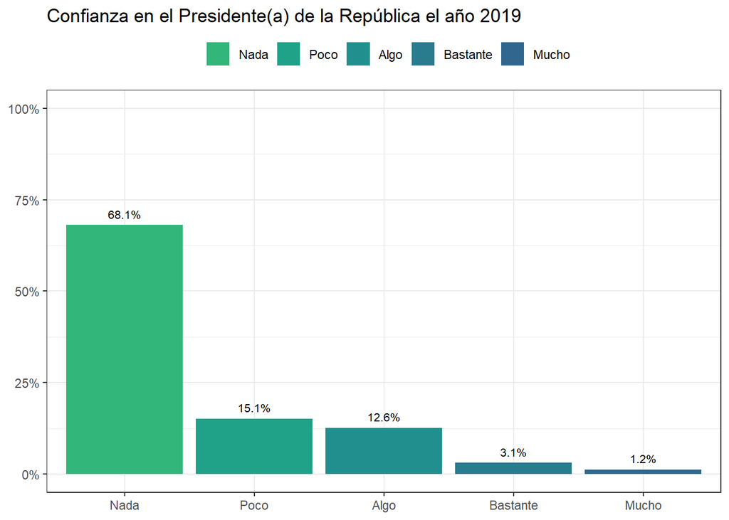

```r
#Para seleccionar sólo un año a analizar, se realiza un subset de los datos a graficar
datos.subset <- droplevels(subset(datos.grafico, datos.grafico$ola == '2019'))
c.1.1 <- datos.subset %>%
    ggplot(aes(y = porcentaje, x = conf_presi, fill = conf_presi,
               label = as.character(scales::percent(porcentaje, accuracy = .1)))) +
  theme_bw() +
    geom_col(position = 'dodge2') +
    scale_y_continuous(labels = scales::percent,
                       limits = c(0, 1)) +
    ylab(label = NULL) +
    xlab(label = NULL) +
    scale_fill_viridis_d(begin = .33, end = .66, direction = -1, option = 'viridis') +
    geom_text(vjust = -0.8,
              position = position_dodge(width = .9),
              size= 2.75) +
    theme(legend.position = 'top',
          legend.title = element_blank()) +
    ggtitle('Confianza en el Presidente(a) de la República el año 2019')
c.1.1
```

##### c.1.2 Grafico de Barras con X = ‘Categoría’

Este tipo de gráficos se utiliza para visualizar respuestas desglosada por año, lo cual es útil en estudios longitudinales debido a su potencial de comparación de las respuestas señaladas por los encuestados en los distintos años de participación.

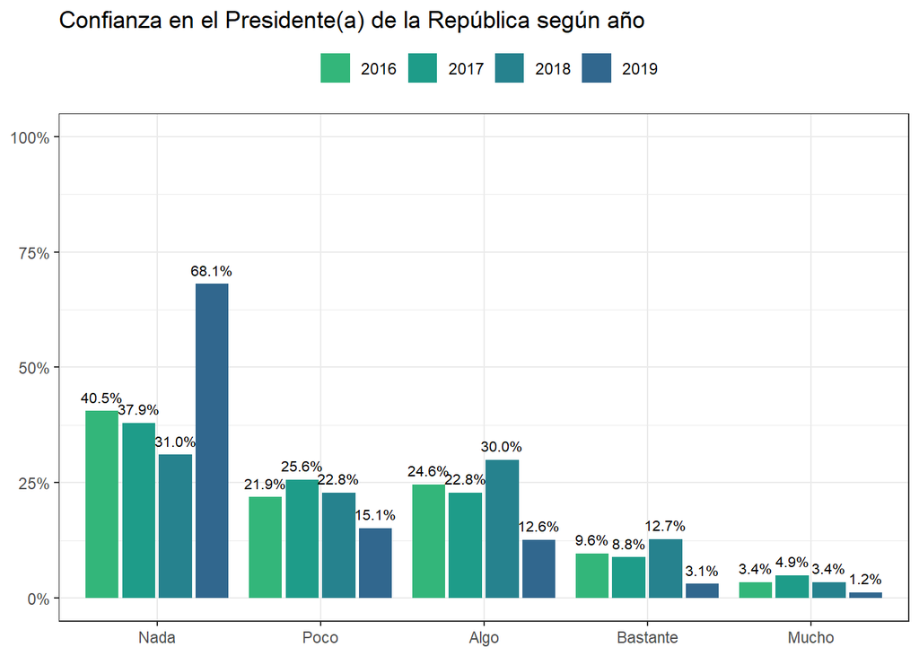

```r
c.1.2 <-datos.grafico %>%
    ggplot(aes(y = porcentaje, x = conf_presi, fill = ola,
               label = as.character(scales::percent(porcentaje, accuracy = .1)))) +
  theme_bw() +
    geom_col(position= 'dodge2') +
    scale_y_continuous(labels = scales::percent,
                       limits = c(0, 1)) +
    ylab(label = NULL) +
    xlab(label = NULL) +
    scale_fill_viridis_d(begin = .33, end = .66, direction = -1, option = 'viridis') +
    geom_text(vjust = -0.8,
              position = position_dodge(width = .9),
              size= 2.75) +
    theme(legend.position = 'top',
          legend.title = element_blank()) +
    ggtitle('Confianza en el Presidente(a) de la República según año')
c.1.2
```

##### c.1.3 Grafico de Barras con X = ‘Ola’ - Dodge

El siguiente gráfico es parecido al anterior en cuanto a su forma, pero muestra una otra manera de expresar la comparación de respuestas por año. Se utiliza para visualizar cada año en forma individual de forma Dodge.

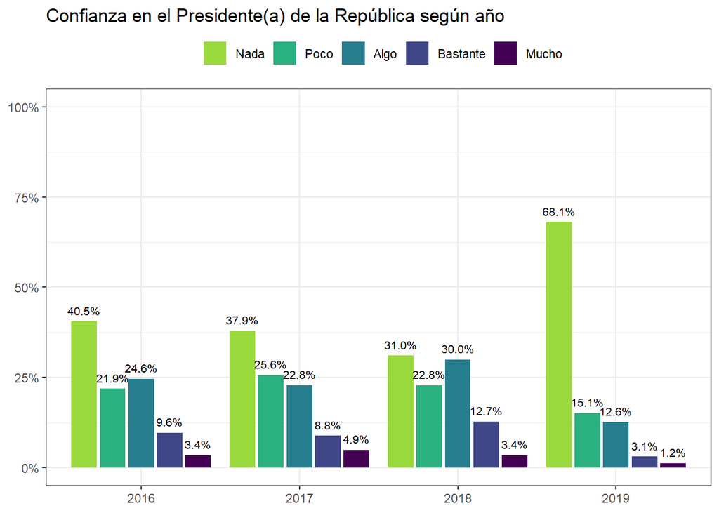

```r
c.1.3 <-datos.grafico %>%
  ggplot(aes(y = porcentaje, x = ola, fill = conf_presi,
             label = as.character(scales::percent(porcentaje, accuracy = .1)))) +
  theme_bw() +
  geom_col(position = 'dodge2') +
  scale_y_continuous(labels = scales::percent,
                     limits = c(0, 1)) +
  ylab(label = NULL) +
  xlab(label = NULL) +
  scale_fill_viridis_d(begin = 0, end = .85, direction = -1, option = 'viridis') +
  geom_text(vjust = -0.8,
            position = position_dodge(width = .9),
            size= 2.75) +
  theme(legend.position = 'top',
        legend.title = element_blank()) +
ggtitle('Confianza en el Presidente(a) de la República según año')
c.1.3
```

##### c.1.4 Grafico de Barras con X = ‘Ola’ - Stack

Este gráfico tiene como finalidad la misma interpretación que el anterior, pero su forma de visualización es distinta. Se utiliza para visualizar cada año en forma individual de forma Stack.

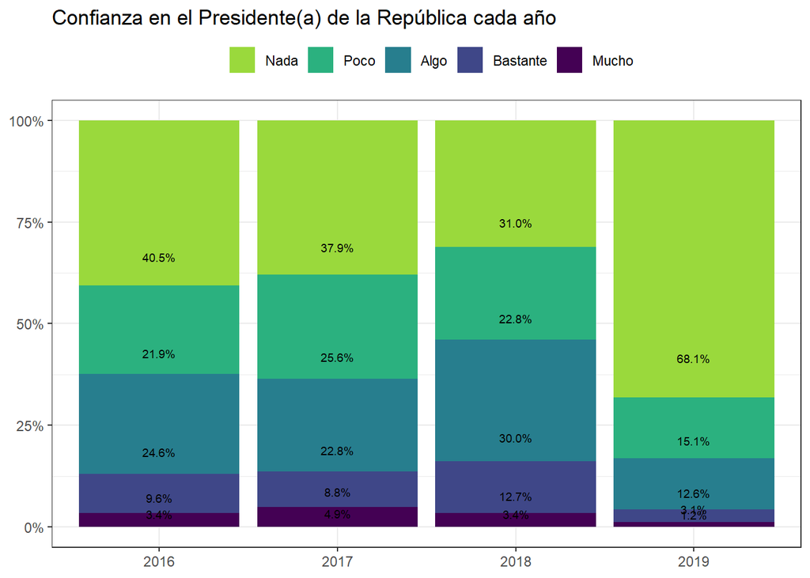

```r
c.1.4 <-datos.grafico %>%
  ggplot(aes(y = porcentaje, x = ola, fill = conf_presi,
             label = as.character(scales::percent(porcentaje, accuracy = .1)))) +
  theme_bw() +
  geom_col(position = 'Stack') +
  scale_y_continuous(labels = scales::percent,
                     limits = c(0, 1)) +
  ylab(label = NULL) +
  xlab(label = NULL) +
  scale_fill_viridis_d(begin = 0, end = .85, direction = -1, option = 'viridis') +
  geom_text(vjust = -0.8,
            position = position_stack(vjust= .1),
            size= 2.55) +
  ##eliminar el texto porque la categoría "Mucho" era muy pequeña y se corría el texto
  theme(legend.position = 'top',
        legend.title = element_blank()) +
  ggtitle('Confianza en el Presidente(a) de la República cada año')
c.1.4
```

#### c.2 Gráficos de barra que relacionan más de dos variables

##### c.2.1 Dos categorías de agrupación: Edad y Ola

En el gráfico se puede ver la comparación etaria respecto a la confianza al presidente de la república, según año. Este gráfico es muy útil para la comparación de variables por agrupación.

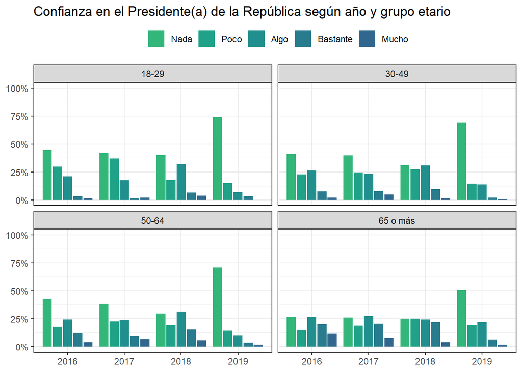

```r
a1 <- data.frame(svytable(~conf_presi + ola + edad, elsoc_diseno, round = T))
a2 <- a1 %>% group_by(edad, ola) %>% transmute(porcentaje=Freq/sum(Freq))
a2$edad <- NULL
a2$ola <- NULL
a1$Freq <- NULL
datos.grafico2<- cbind(a1,a2)
c.2.1 <-datos.grafico2 %>%
    ggplot(aes(y = porcentaje, x = ola, fill = conf_presi,
               label = as.character(scales::percent(porcentaje, accuracy = .1)))) +
  theme_bw() +
    geom_col(position = 'dodge2') +
    scale_y_continuous(labels = scales::percent,
                       limits = c(0, 1)) +
    ylab(label = NULL) +
    xlab(label = NULL) +
    scale_fill_viridis_d(begin = .33, end = .66, direction = -1, option = 'viridis') +
    facet_wrap(datos.grafico2$edad)+
    theme(legend.position = 'top',
          legend.title = element_blank()) +
    ggtitle('Confianza en el Presidente(a) de la República según año y grupo etario')
c.2.1
```

##### c.2.2 Grafico de Barra para tres variables por Ola

En el siguiente gráfico se muestra los % de respuesta respecto a la confianza en carabineros, partidos políticos y presidente/a de la república. En este sentido, puede ser útil incorporar este tipo de gráfico si se desea comparar las respuestas por año de 3 variables.

```r
a <- data.frame(svytable(~conf_presi + ola, elsoc_diseno, round = T))
a1 <- a %>% group_by(ola) %>% transmute(p_presi=Freq/sum(Freq))
b <- data.frame(svytable(~conf_part + ola, elsoc_diseno, round = T))
b1 <- b %>% group_by(ola) %>% transmute(p_part=Freq/sum(Freq))
c <- data.frame(svytable(~conf_carb + ola, elsoc_diseno, round = T))
c1 <- c %>% group_by(ola) %>% transmute(p_carb=Freq/sum(Freq))
datos.grafico2<- cbind(a,a1,b,b1,c,c1)

datos.grafico <- datos.grafico2 %>%
        pivot_longer(cols = starts_with('conf_'))  %>%
        mutate(variable = factor(name,
                             labels = c('Presidente/a de la Republica', 'Partidos Políticos',
                             'Carabineros de Chile'))) %>%
                                        drop_na()

datos.grafico$porcentaje <- with(datos.grafico, case_when(
  variable == 'Carabineros de Chile' ~ p_carb,
  variable == 'Presidente/a de la Republica' ~ p_presi,
  variable == 'Partidos Políticos' ~ p_part))
```

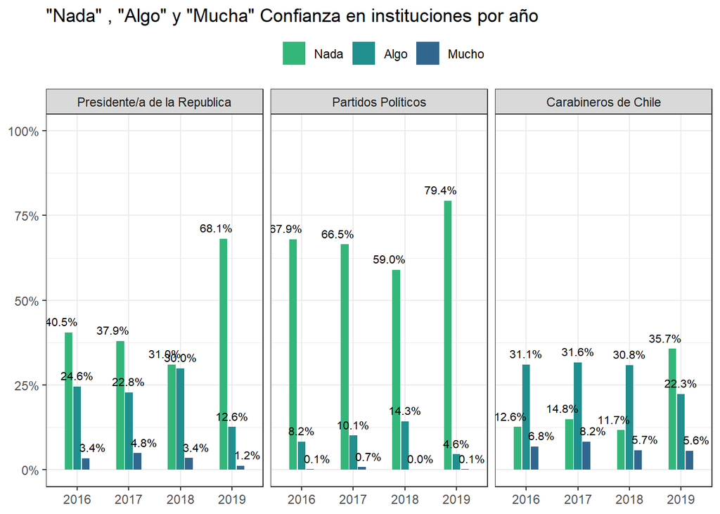

```r
datos.subset <- droplevels(subset(datos.grafico,
                                  value == 'Nada' |
                                    value == 'Algo'|
                                    value == 'Mucho'))
c.2.2 <-datos.subset %>%
    ggplot(aes(y = porcentaje, x = ola, fill = value,
               label = as.character(scales::percent(porcentaje, accuracy = .1)))) +
  theme_bw() +
    geom_col(width = 0.5, position = "dodge2") +
    scale_y_continuous(labels = scales::percent,
                       limits = c(0, 1)) +
    ylab(label = NULL) +
    xlab(label = NULL) +
    scale_fill_viridis_d(begin = .33, end = .66, direction = -1, option = 'viridis') +
    facet_grid(.~variable) +
    geom_text(vjust = -0.8,
              position = position_dodge(width = .9),
              size= 2.75) +
    theme(legend.position = 'top',
        legend.title = element_blank()) +
    ggtitle('"Nada" , "Algo" y "Mucha" Confianza en instituciones por año')
c.2.2
```

##### c.2.3 Grafico de Barra para medir cambio en el tiempo de una variable

El último gráfico muestra el cambio de la percepción del estatus social a lo largo del tiempo. Lo interesante de este gráfico es la posibilidad de agrupar años para una mejor y más clara visualización. Este tipo de gráficos se puede utilizar si es que se quiere percibir cambios a nivel macro de alguna variable.

- Recolectar variables que utilizaré

```r
datos.grafico3 <- data.frame(cbind(elsoc_long$idencuesta, elsoc_long$ola,elsoc_long$estatus,
                                   elsoc_long$ponderador02))
colnames(datos.grafico3) <- c("idencuesta", "ola", "estatus", "ponderador02")
```

- Pasar tabla de long a wide

```r
datos.grafico3 <- panel_data(datos.grafico3, id = idencuesta, wave = ola)
datos.wide <- widen_panel(datos.grafico3, separator = "_")
```

- Recodificar cambios

```r
datos.wide$cambio_estatus_4 <- factor(with(datos.wide, case_when(
    estatus_4 == estatus_3 & !is.na(estatus_4) & !is.na(estatus_3) ~ 2,
    estatus_4 > estatus_3  & !is.na(estatus_4) & !is.na(estatus_3) ~ 1,
    estatus_4 < estatus_3  & !is.na(estatus_4) & !is.na(estatus_3) ~ 3)),
    labels = c('Aumenta', 'Se mantiene', 'Disminuye'))
datos.wide$cambio_estatus_3 <- factor(with(datos.wide, case_when(
    estatus_3 == estatus_2 & !is.na(estatus_3) & !is.na(estatus_2) ~ 2,
    estatus_3 > estatus_2  & !is.na(estatus_3) & !is.na(estatus_2) ~ 1,
    estatus_3 < estatus_2  & !is.na(estatus_3) & !is.na(estatus_2) ~ 3)),
    labels = c('Aumenta', 'Se mantiene', 'Disminuye'))
datos.wide$cambio_estatus_2 <- factor(with(datos.wide, case_when(
    estatus_2 == estatus_1 & !is.na(estatus_2) & !is.na(estatus_1) ~ 2,
    estatus_2 > estatus_1  & !is.na(estatus_2) & !is.na(estatus_1) ~ 1,
    estatus_2 < estatus_1  & !is.na(estatus_2) & !is.na(estatus_1) ~ 3)),
    labels = c('Aumenta', 'Se mantiene', 'Disminuye'))
```

```r
datos.grafico <- datos.wide %>%
  pivot_longer(cols = c(cambio_estatus_2,cambio_estatus_3,cambio_estatus_4), names_to = "cambio_estatus",
               values_to = "respuesta") %>%
               drop_na()%>%
               group_by(cambio_estatus, respuesta) %>%
               summarise(n1=sum(ponderador02_1,na.rm=T)) %>%
               mutate(n2 = sum(n1, na.rm = TRUE), porcentaje = n1/n2)%>%
               ungroup()
```

- Recodificamos los periodos de cambio

```r
datos.grafico$cambio_estatus<- car::recode(datos.grafico$cambio_estatus,
                           "'cambio_estatus_2'='2016-2017';'cambio_estatus_3'='2017-2018';
                           'cambio_estatus_4'='2018-2019'")
```

- Finalmente, creamos el gráfico.

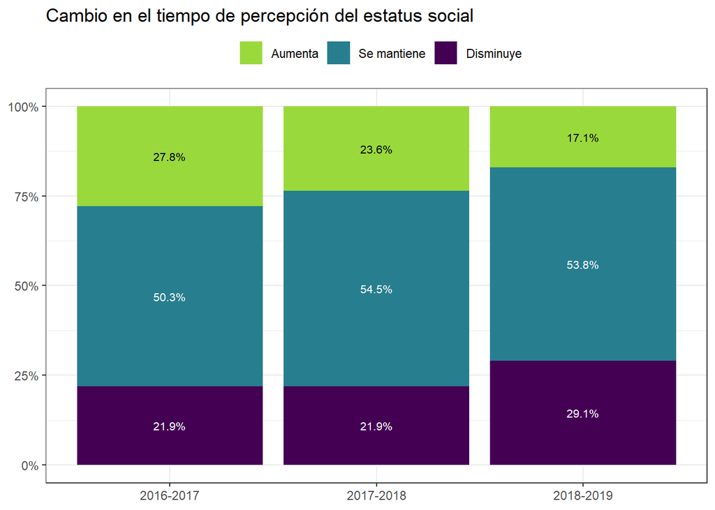

```r
c.2.3 <-ggplot(datos.grafico, aes(y=porcentaje, x=cambio_estatus,fill=respuesta ,label =
                                    as.character(scales::percent(porcentaje, accuracy = .1))))+
    theme_bw()+
  geom_col(position = "stack") +
  scale_y_continuous(labels = scales::percent,
                     limits = c(0, 1)) +
  ylab(label = NULL) +
  xlab(label = NULL) +
  scale_fill_viridis_d(begin = 0, end = .85, direction = -1, option = 'viridis') +
  theme(legend.position = 'top',
        legend.title = element_blank()) +
  geom_text(position = position_stack(vjust = .5),
            size= 2.75,
            color = rep(c('black', 'white', 'white'), 3))+
    ggtitle('Cambio en el tiempo de percepción del estatus social')
c.2.3
```

### d. Gráficos Alluvial

En esta sección aprenderá a realizar gráficos “alluvial” para datos longitudinales. Este tipo de gráfico permite visualizar los cambios en la distribución de frecuencias para variables categóricas a lo largo del tiempo. Previo a la visualización de este tipo de gráfico, se siguen dos pasos necesarios para la correcta especificación de variables, a saber:

**Paso 1**: Crear una base de datos que agrupa la frecuencia de la variables de interés por otra variable de agrupación (ej. `ola`).

**Paso 2**: Crear una tabla que agrupa frecuencias en función de las categorías de respuesta tanto de la variable de interés como de la variable de agrupación (ej. `ola`)

#### d.1 Alluvial para una variable en cuatro olas: identificación con coalición política.

```r
#Paso 1
datos.grafico.d.1 <- elsoc_long %>%
    group_by(idencuesta,ola,idcoal) %>%
    summarise(n1=sum(ponderador02,na.rm=T)) %>%
    group_by(ola) %>%
    mutate(n2 = sum(n1, na.rm = TRUE), porcentaje = n1/n2)%>%
    ungroup()

#Paso 2
etiquetas.grafico.d.1 <- datos.grafico.d.1 %>%
    group_by(ola,idcoal) %>%
    summarise(porcentaje = sum(porcentaje, na.rm = TRUE)) %>%
    mutate(idencuesta = 1)
```

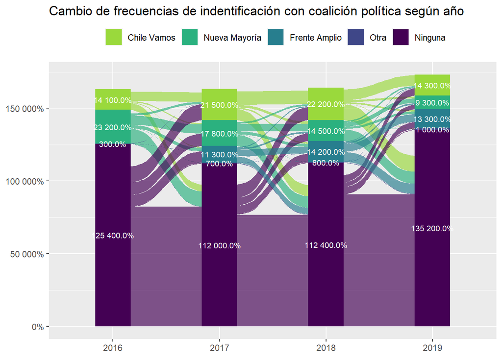

```r
d.1 <- ggplot(datos.grafico.d.1, aes(x = ola, fill = idcoal, stratum = idcoal,
                             alluvium = idencuesta, y = porcentaje)) +
    ggalluvial::geom_flow(alpha = .66) +
    ggalluvial::geom_stratum(linetype = 0) +
    scale_y_continuous(labels = scales::percent) +
    ylab(label = NULL) +
    xlab(label = NULL) +
    theme(legend.position = 'top',
          legend.title = element_blank()) +
    scale_fill_viridis_d(begin = 0, end = .85, direction = -1, option = 'viridis') +
    geom_text(data = etiquetas.grafico.d.1,
              aes(label = scales::percent(porcentaje, accuracy = .1)),
              position = position_stack(vjust = .5),
              show.legend = FALSE,
              size = 2.75,
              color = rep('white'))+
  ggtitle('Cambio de frecuencias de indentificación con coalición política según año')

d.1
```

#### d.2 Alluvial para dos olas: identificación con coalición política.

```r
#Paso 1
datos.grafico.d.2 <- elsoc_long %>%
    group_by(idencuesta,idcoal,ola) %>%
    summarise(n1 = sum(ponderador02, na.rm = TRUE)) %>%
    group_by(ola) %>%
    mutate(n2 = sum(n1, na.rm = TRUE), porcentaje = n1/n2) %>%
    ungroup()
#Paso 1.1: crear un subset que incluya la frecuencia de la variable de interés sólo para los años 2017 y 2019
datos.subset.d.2 <- droplevels(subset(datos.grafico.d.2, datos.grafico.d.2$ola == '2017' | datos.grafico.d.2$ola == '2019'))

#Paso 2
etiquetas.grafico.d.2 <- datos.subset.d.2 %>%
    group_by(idcoal,ola) %>%
    summarise(porcentaje = sum(porcentaje, na.rm = TRUE)) %>%
    mutate(idencuesta = 1)
```

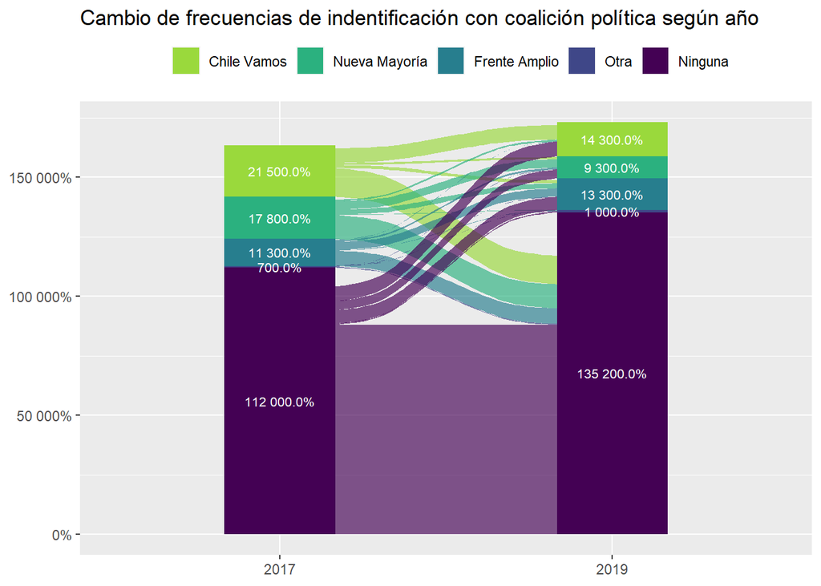

```r
d.2 <- ggplot(datos.subset.d.2, aes(x = ola, fill = idcoal, stratum = idcoal,
               alluvium = idencuesta, y = porcentaje)) +
    ggalluvial::geom_flow(alpha = .66) +
    ggalluvial::geom_stratum(linetype = 0) +
    scale_y_continuous(labels = scales::percent) +
    ylab(label = NULL) +
    xlab(label = NULL) +
    theme(legend.position = 'top',
          legend.title = element_blank()) +
    scale_fill_viridis_d(begin = 0, end = .85, direction = -1, option = 'viridis') +
    geom_text(data = etiquetas.grafico.d.2,
              aes(label = scales::percent(porcentaje, accuracy = .1)),
              position = position_stack(vjust = .5),
              show.legend = FALSE,
              size = 2.75,
              color = rep('white')) +
    ggtitle('Cambio de frecuencias de indentificación con coalición política según año')

d.2
```

#### d.3 Alluvial para dos o más categorías: situación ocupacional

```r
#Paso 1:
datos.grafico.d.3 <- elsoc_long %>%
    group_by(idencuesta,socup,sexo,ola) %>%
    summarise(n1 = sum(ponderador02, na.rm = TRUE)) %>%
    group_by(ola,sexo) %>%
    mutate(n2 = sum(n1, na.rm = TRUE), porcentaje = n1/n2) %>%
    ungroup()
#Paso 1.1: crear un subset que incluya la frecuencia de la variable de interés sólo para los años 2017 y 2019
datos.subset.d.3 <- droplevels(subset(datos.grafico.d.3, datos.grafico.d.3$ola == '2017' | datos.grafico.d.3$ola == '2019'))

#Paso 2:
etiquetas.grafico.d.3 <- datos.subset.d.3 %>%
    group_by(socup,ola, sexo) %>%
    summarise(porcentaje = sum(porcentaje, na.rm = TRUE)) %>%
    mutate(idencuesta = 1)
```

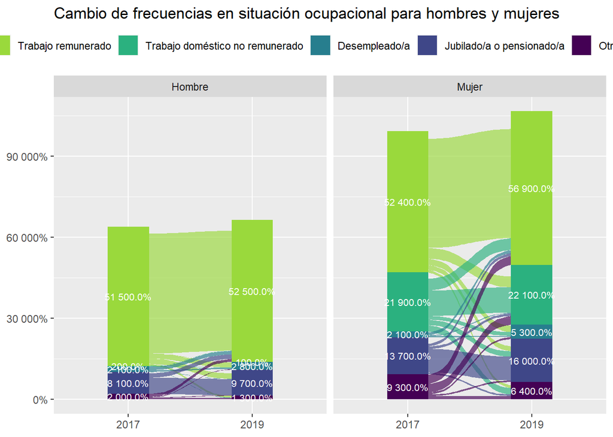

```r
d.3 <- ggplot(datos.subset.d.3, aes(x = ola, fill = socup, stratum = socup,
               alluvium = idencuesta, y = porcentaje)) +
    ggalluvial::geom_flow(alpha = .66) +
    ggalluvial::geom_stratum(linetype = 0) +
    scale_y_continuous(labels = scales::percent) +
    ylab(label = NULL) +
    xlab(label = NULL) +
    theme(legend.position = 'top',
          legend.title = element_blank()) +
    scale_fill_viridis_d(begin = 0, end = .85, direction = -1, option = 'viridis') +
    facet_wrap(.~sexo)+
    geom_text(data = etiquetas.grafico.d.3,
              aes(label = scales::percent(porcentaje, accuracy = .1)),
              position = position_stack(vjust = .5),
              show.legend = FALSE,
              size = 2.75,
              color = rep('white'))+
  ggtitle('Cambio de frecuencias en situación ocupacional para hombres y mujeres')

d.3
```

### e. Gráficos de lineas.

En esta sección aprenderá a realizar gráficos de lineas y puntos para datos longitudinales. Este tipo de gráfico permite visualizar los cambios de frecuencia para variables categóricas a lo largo del tiempo. Al igual que la sección anterior, se siguen dos pasos necesarios para la correcta especificación de variables, a saber:

**Paso 1**: Crear una base de datos que agrupa la frecuencia de la variables de interés por otra variable de agrupación (ej. `ola`).

**Paso 2**: Crear una tabla que agrupa frecuencias en función de las categorías de respuesta tanto de la variable de interés como de la variable de agrupación (ej. `ola`)

#### e.1 Lineas y puntos para una variable.

```r
#Paso 1:
datos.grafico.e.1 <- elsoc_long %>%
    dplyr::filter(!is.na(conf_presi)) %>%
    group_by(idencuesta,conf_presi,ola) %>%
    summarise(n1 = sum(ponderador02, na.rm = TRUE)) %>%
    group_by(ola) %>%
    mutate(n2 = sum(n1, na.rm = TRUE), porcentaje = n1/n2) %>%
    ungroup()

#Paso 2:
etiquetas.grafico.e.1 <- datos.grafico.e.1 %>%
    group_by(conf_presi,ola) %>%
    summarise(porcentaje = sum(porcentaje, na.rm = TRUE)) %>%
    mutate(idencuesta = 1)
```

[figure not shown]

```r
e.1 <- ggplot(etiquetas.grafico.e.1,aes(y = porcentaje, x = ola, color = conf_presi, group = conf_presi,
               label = as.character(scales::percent(porcentaje, accuracy = .1)))) +
    geom_line(size = 1) +
    geom_point(size = 1.8) +
    scale_y_continuous(labels = scales::percent,
                       limits = c(0,.8)) +
    ylab(label = NULL) +
    xlab(label = NULL) +
    scale_color_viridis_d(begin = .2, end = .5, direction = 1, option = 'viridis') +
    geom_text(vjust = -0.8,
    posilinetion = position_dodge(width = .9),
    size= 2.75) +
    theme(legend.position = 'top',
          legend.title = element_blank())

e.1
```

#### e.2 Lineas y puntos para más de una variable.

```r
#Paso 1:
datos.grafico.e.2 <- elsoc_long %>%
    group_by(idencuesta,conf_presi,conf_part,conf_carb,ola) %>%
    summarise(n1 = sum(ponderador02, na.rm = TRUE)) %>%
    group_by(ola) %>%
    mutate(n2 = sum(n1, na.rm = TRUE), porcentaje = n1/n2) %>%
    ungroup()
#Paso 1.1: creamos un subset con una nueva variables llamada "conf nada", que integra todas las respuesta "Nada" a la pregunta por la confianza en tres instituciones: presidente, partidos político y carabineros.
datos.subset.e.2 <- datos.grafico.e.2 %>%
        pivot_longer(cols = starts_with('conf_'), names_to = 'conf_nada')
#Paso 1.2: renombramos los valores de la variable "conf_nada".
datos.subset.e.2$conf_nada <- factor(datos.subset.e.2$conf_nada,
                            labels = c('Confianza en el Presidente', 'Confianza en Partidos Políticos',
                                       'Confianza en Carabineros'))
#Paso 1.3: filtramos el subset a fin de dajer sólo las respuestas "Nada" de confianza en las tres instituciones mencionadas.
datos.subset.e.2a <- droplevels(subset(datos.subset.e.2, value == 'Nada'))

#Paso 2:
etiquetas.grafico.e.2a <- datos.subset.e.2a %>%
    group_by(conf_nada,ola) %>%
    summarise(porcentaje = sum(porcentaje, na.rm = TRUE)) %>%
    mutate(idencuesta = 1)
```

[figure not shown]

```r
e.2 <- ggplot(etiquetas.grafico.e.2a,aes(y = porcentaje, x = ola, color = conf_nada, group = conf_nada,
               label = as.character(scales::percent(porcentaje, accuracy = .1)))) +
    geom_line(size = 1) +
    geom_point(size = 1.8) +
    scale_y_continuous(labels = scales::percent,
                       limits = c(0,.8)) +
    ylab(label = NULL) +
    xlab(label = NULL) +
    scale_color_viridis_d(begin = .2, end = .5, direction = 1, option = 'viridis') +
    geom_text(vjust = -0.8,
    posilinetion = position_dodge(width = .9),
    size= 2.75) +
    theme(legend.position = 'top',
          legend.title = element_blank()) +
    ggtitle('Cambio de frecuencias en el grado de confianza "Nada" en algunas instituciones')

e.2
```

#### e.3 Lineas y puntos para una variables y más de una agrupación

```r
#Paso 1:
datos.grafico.e.3 <- elsoc_long %>%
    group_by(idencuesta,conf_presi,conf_part,conf_carb,zona,ola) %>%
    summarise(n1 = sum(ponderador02, na.rm = TRUE)) %>%
    group_by(ola,zona) %>%
    mutate(n2 = sum(n1, na.rm = TRUE), porcentaje = n1/n2) %>%
    ungroup()
#Paso 1.1
datos.subset.e.3 <- datos.grafico.e.3 %>%
        pivot_longer(cols = starts_with('conf_'), names_to = 'conf_nada')
#Paso 1.2
datos.subset.e.3$conf_nada <- factor(datos.subset.e.2$conf_nada,
                            labels = c('Confianza en el Presidente', 'Confianza en Partidos Políticos',
                                       'Confianza en Carabineros'))
#Paso 1.3
datos.subset.e.3a <- droplevels(subset(datos.subset.e.3, value == 'Nada'))

#Paso 2:
etiquetas.grafico.e.3a <- datos.subset.e.3a %>%
    group_by(conf_nada,ola,zona) %>%
    summarise(porcentaje = sum(porcentaje, na.rm = TRUE)) %>%
    mutate(idencuesta = 1)
```

[figure not shown]

```r
e.3 <- ggplot(etiquetas.grafico.e.3a,aes(y = porcentaje, x = ola, color = conf_nada, group = conf_nada,
               label = as.character(scales::percent(porcentaje, accuracy = .1)))) +
    geom_line(size = 1) +
    geom_point(size = 1.8) +
    scale_y_continuous(labels = scales::percent,
                       limits = c(0,.9)) +
    ylab(label = NULL) +
    xlab(label = NULL) +
    scale_color_viridis_d(begin = .2, end = .5, direction = 1, option = 'viridis') +
    facet_wrap(.~zona)+
    geom_text(vjust = -0.8,
    posilinetion = position_dodge(width = .9),
    size= 2.75) +
    theme(legend.position = 'top',
          legend.title = element_blank()) +
    ggtitle('Cambio de frecuencias en el grado de confianza "Nada" en algunas instituciones')

e.3
```